# How Easily Influenced is Sofia?

## Working Hard or Hardly Working?

An exploration into the number and type of advertisement that I encounter on my multiple daily scrolls through Instagram and TikTok.

## When is Sofia the Most Distracted?

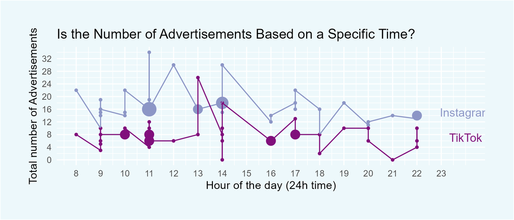

This visualisation displays the number of advertisements per hour on both TikTok and Instagram. At first glance, the line graph allows you to see the time periods where there are peaks in the number of advertisements (between 11 and 2 for both platforms). It is also easy to grasp that Instagram almost consistently has a higher number of advertisements compared to TikTok, no matter the time of day. If you want a little additional information, the size of the dots provide information regarding what amounts of ads were most common eg. the bigger the dot, the more times that number of advertisements occurred in that specific hour. Bonus points to anyone who can guess what time I generally wake up and what time I go to sleep.

## Wait, but what were these advertisements about?

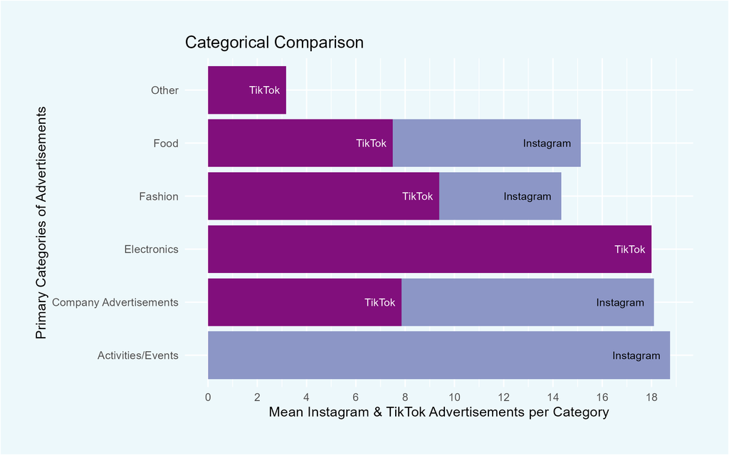

Mean Amount of Ads Categorical Comparsion

When I gathered my data, the primary category of the advertisements for each 10 minute period was also recorded. This plot displays the mean number of advertisements across each 10 minute period of advertisements of each specific primary category. Immediately, you can infer that the advertisements are not the same across the two platforms, as TikTok has a large amount of “Electronic” advertisements while Instagram has a large amount of “Activities/Events” advertisements. This means that you can also infer that Instagrams advertisments are more specific to Auckland, (side note: how does it know my location), while TikToks may be more general and could perhaps be similar across all users who speak a specific language. Without knowing what advertisements other people are getting it is difficult to gather whether these advertisements are specific to my interests or not, but the Fashion and Food advertisements across both platforms could sway the vote towards yes.

## Do I Really Care?

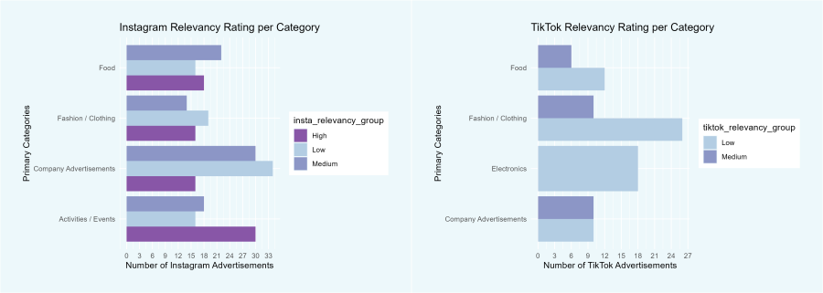

I mentioned in my Project 2 report that while recording this data may seem mundane, it was actually eye-opening to me as I did not notice how many advertisements I simply blocked out and did not take any notice of. Is it concerning that I have spent so much time on social media that my brain has wired itself to mentally block out all advertisements? This plot consists of two separate plots grouped together which can be viewed separately or used for comparison. Each plot displays the main categories of advertisements on each platform alongside the number of advertisements in each category which I rated as high, medium or low relevance to me. A general overview of the two graphs allows you to see that I did not find TikTok advertisements relevant to me at all, as no ads received a “high” classification. Zooming in on the TikTok graph you can see that no category of advertisements contained advertisements that I found particularly invigorating or relevant to me. However, in the Instagram graph you can see that I found advertisements in the “Activites/Events” category more relevant to me, presumably because they were specific to Auckland and included something that I might actually attend.